# Reseaux de neurones profonds avec TensorFlow

# 1 Introduction

On va modeliser ici une cible multi-classe a l’aide de l’interface Keras qui a ete integree a TensorFlow. Elle permet une modelisation rapide et fournit des sorties graphiques sur la qualite du modele.

On reprend le jeu de donnees et les pretraitements du document precedent sur TensorFlow.

### 1.0.1 Donnees et modules

```r
library("reticulate")

# on a installe tensorflow dans l'environnement vituel conda "tf_env"
use_condaenv(condaenv = "tf_env")

data(package = "arules", IncomeESL)

dtf_class = tidyr::drop_na(IncomeESL)
colnames(dtf_class) = gsub(" ", "_", colnames(dtf_class))

dtf_class = dtf_class[c("number_in_household", "marital_status", "householder_status", "income")]

dtf_class$number_in_household = as.character(dtf_class$number_in_household)
dtf_class$number_in_household[dtf_class$number_in_household == "9+"]= "9"
dtf_class$number_in_household = as.integer(dtf_class$number_in_household)

for (col_quali in colnames(dtf_class)[sapply(dtf_class, is.factor)]) {
  dtf_class[[col_quali]] = as.character(dtf_class[[col_quali]] )
}

dtf_class$income = gsub(",", "-", dtf_class$income)
```

```python
import numpy as np
import pandas as pd
pd.set_option('display.max_columns', None)

import sys
import shutil
import pprint
pp = pprint.PrettyPrinter(indent=4)

from sklearn.model_selection import train_test_split

import tensorflow as tf
from tensorflow import feature_column
from tensorflow.keras import layers

# pour regler un bug graphique assez courant avec Anaconda,
# adapter le chemin vers le dossier 'plugins/platforms'
import os
from os import path
os.environ['QT_QPA_PLATFORM_PLUGIN_PATH'] = 'C:/Users/Sebastien/Anaconda3/Library/plugins/platforms'
os.chdir(".")

import matplotlib.pyplot as plt
import seaborn as sns
sns.set()

tf.random.set_seed(2021)
```

Les versions Python et TensorFlow utilisees.

```python
sys.version
tf.__version__
```

```
'3.9.6 (default, Jul 30 2021, 11:42:22) [MSC v.1916 64 bit (AMD64)]'
'2.6.0'
```

Les donnees sous Python.

```python
dtf_class = r.dtf_class

dtf_class.head()
```

```
   number_in_household marital_status        householder_status   income
0                    5        married                       own      75+
1                    3        married                      rent      75+
2                    4         single  live with parents/family   [0-10)
3                    4         single  live with parents/family   [0-10)
4                    2        married                       own  [50-75)
```

Frequences des modalites de la cible.

```python
dtf_class.income.value_counts(normalize=True).sort_index()
```

```
75+        0.108057
[0-10)     0.182519
[10-15)    0.076934
[15-20)    0.073444
[20-25)    0.089878
[25-30)    0.076643
[30-40)    0.123037
[40-50)    0.114020
[50-75)    0.155468
Name: income, dtype: float64
```

Dictionnaire pour recoder la variable cible.

```python
# mapping pour recoder les modalites cibles en entiers
dico_income = {'[0-10)':0,'[10-15)':1,'[15-20)':2, '[20-25)':3,'[25-30)':4, '[30-40)':5, '[40-50)':6, '[50-75)':7,'75+':8}
dico_income_bin = {'[0-10)':0,'[10-15)':0,'[15-20)':0, '[20-25)':0,'[25-30)':0, '[30-40)':1, '[40-50)':1, '[50-75)':1,'75+':1}
pp.pprint(dico_income)
pp.pprint(dico_income_bin)
```

```
{   '75+': 8,
    '[0-10)': 0,
    '[10-15)': 1,
    '[15-20)': 2,
    '[20-25)': 3,
    '[25-30)': 4,
    '[30-40)': 5,
    '[40-50)': 6,
    '[50-75)': 7}
{   '75+': 1,
    '[0-10)': 0,
    '[10-15)': 0,
    '[15-20)': 0,
    '[20-25)': 0,
    '[25-30)': 0,
    '[30-40)': 1,
    '[40-50)': 1,
    '[50-75)': 1}
```

### 1.0.2 Pretraitement des colonnes

```python
feature_columns = []

# numeriques
feature_columns.append(feature_column.numeric_column("number_in_household"))

# en buckets
number_in_household = feature_column.numeric_column("number_in_household")
number_bucket = tf.feature_column.bucketized_column(number_in_household, boundaries = [3, 5, 7])
feature_columns.append(number_bucket)

# indicatrices
marital_status = tf.feature_column.categorical_column_with_vocabulary_list(
  'marital_status', ['single', 'married', 'divorced', 'cohabitation'', widowed'])
marital_one_hot = tf.feature_column.indicator_column(marital_status)
feature_columns.append(marital_one_hot)

# embedding
householder_status = tf.feature_column.categorical_column_with_vocabulary_list(
  'householder_status', ['own', 'rent', 'live with parents/family'])
householder_embedding = tf.feature_column.embedding_column(householder_status, dimension = 2)
feature_columns.append(householder_embedding)

# interactions
interactions = tf.feature_column.crossed_column([marital_status, number_bucket],
hash_bucket_size = 7, hash_key = 8)
interactions = tf.feature_column.indicator_column(interactions)
feature_columns.append(interactions)
```

Dictionnaire pour la lisibilite des operations effectuees, une liste suffirait techniquement.

```python
feature_columns = {"number_in_household":feature_column.numeric_column("number_in_household"),
  "number_bucket": number_bucket,
  "marital_one_hot": marital_one_hot,
  "householder_embedding": householder_embedding,
  "interactions": interactions
  }
```

### 1.0.3 Fonction de lecture des donnees

Par defaut on considere que la cible est multi-classes et on recode ses modalites de 0 a 8. Si on prend *dico = dico_income_bin* on considere que la cible est binaire et recodee en 0/1.

```python
# on cree un tf.data.dataset a patir du Dataframe
def df_to_dataset(dataframe, shuffle = True, batch_size = 32, dico = dico_income, nb_repet = None):
  dataframe = dataframe.copy()
  labels = dataframe.pop('income').map(dico)
  ds = tf.data.Dataset.from_tensor_slices((dict(dataframe), labels))
  if shuffle:
    # permutation dde toutes les lignes du dataframe car seulement quelques milliers de lignes
    ds = ds.shuffle(buffer_size = len(dataframe))
  ds = ds.repeat(count = nb_repet).batch(batch_size)
  return ds
```

# 2 Modelisation Sequentielle avec Keras

### 2.0.1 Train, test, validation

Les trois jeux de donnees pour l’apprentissage, les validations et le test final.

```python
# test = 20% du total
train, test = train_test_split(dtf_class, test_size=0.2, random_state = 2021)
# val = 25% du train = 20% du total
train, val = train_test_split(train, test_size=0.25, random_state = 2021)
```

### 2.0.2 Parametres et metriques

#### 2.0.2.1 Architecture du modele

Un reseau de neurones avec Keras Sequentiel est une succession de couches de neurones, ici on a :

- une couche *DenseFeatures* de conversion des entrees en tenseurs
- deux couches cachees avec respectivement 16 et 8 neurones et la fonction d’activation standard “relu” pour les couches cachees
- une couche *Dropout* qui s”applique a la couche precedente de 8 neurones. Elle permet de lutter contre le surapprentissage en supprimant avec une probabilite de 20% chacun des 8 neurones lors de l’entrainement du reseau. Ca n’a de reel interet que pour des reseaux vraiments profonds, c’est-a-dire avec de nombreuses couches cachees.
- une couche de sortie avec un score par modalite de la cible. La fonction *softmax* generalise la sigmoide qui ne s’applique qu’aux cibles binaires.

Le nombre de couches cachees, le nombre de neurones de chaque couche et le taux de dropout sont autant d’hyperparametres a optimiser.

```python
modele_softmax = tf.keras.Sequential([
  layers.DenseFeatures(feature_columns = feature_columns.values()),
  layers.Dense(16, activation = 'relu', name = "hidden1"),
  layers.Dense(8, activation = 'relu', name = "hidden2"),
  layers.Dropout(0.2),
  layers.Dense(len(dico_income), activation = 'softmax', name = "output")
])
```

Une variante avec cible binaire.

```python
modele_binaire = tf.keras.Sequential([
  layers.DenseFeatures(feature_columns = feature_columns.values()),
  layers.Dense(16, activation = 'relu', name = "hidden1"),
  layers.Dense(8, activation = 'relu', name = "hidden2"),
  layers.Dropout(0.2),
  layers.Dense(1, activation = 'sigmoid', name = "output")
])
```

#### 2.0.2.2 Autres parametres

On precise la valeur de certains parametres dans la fonction *compile* plus bas :

- hyperparametre *optimizer* : le choix de l’algorithme de descente de gradient, ils n’ont pas tous les memes parametres. Ainsi l’optimiseur *Ftrl* propose des ratios de regularisation, voir https://www.tensorflow.org/api_docs/python/tf/keras/optimizers/Ftrl
- hyperparametre *loss* : la fonction de perte a minimiser par l’algorithme de descente de gradient, la “cross-entropy” n’est rien d’autre que l’oppose de la log-vraisemblance
  - *tf.keras.losses.BinaryCrossentropy* (ou ‘binary_crossentropy’) en cas de cible binaire 0/1
  - *tf.keras.losses.CategoricalCrossentropy* (ou ‘categorical_crossentropy’) si cible multi-classes au format “une indicatrice par classe”
  - *tf.keras.losses.SparseCategoricalCrossentropy* (ou ‘sparse_categorical_crossentropy’) si cible multi-classes au format “colonne d’entiers”
- *metrics* : les metriques metiers classiques pour evaluer la performance du modele. Les metriques ne sont pas des hyperparametres du modele : elles n’interviennent pas dans l’entrainement du modele. Si la cible est binaire on a entre autres
  - l’AUC
  - l’exactitude toujours fournie par defaut
  - la precision
  - le rappel
  - les metriques de comptages des vrais positifs, faux negatifs, … de la matrice de confusion

Des metriques pour le cas d’une cible binaire.

```python
metriques_bin = [tf.keras.metrics.AUC(name='auc'),
  tf.keras.metrics.BinaryAccuracy(name='accuracy'),
  tf.keras.metrics.Precision(name='precision'),
  tf.keras.metrics.Recall(name='recall'),
  tf.keras.metrics.TruePositives(name='tp'),
  tf.keras.metrics.FalsePositives(name='fp'),
  tf.keras.metrics.TrueNegatives(name='tn'),
  tf.keras.metrics.FalseNegatives(name='fn')
  ]
```

#### 2.0.2.3 Dependances entre hyperparametres

On suit les recommandations de l’article https://medium.com/google-cloud/ml-design-pattern-3-virtual-epochs-f842296de730 qui deconseille de choisir directement le nombre d’epoques ou d’etapes (c’est-a-dire de mini-batchs) mais plutot

- la taille des mini-batchs : *TRAIN_BATCH_SIZE*
- le nombre total d’exemples montres au modele pendant son entrainement : *NUM_TRAIN_EXAMPLES*
- le nombre de checkpoints, a chaque checkpoint on stocke les performances du modele qu’on va representer graphiquement : *NUM_CHECKPOINTS*

Ici les “epoques” sont virtuelles et ne correspondent pas tout a fait a la lecture de tout le dataframe, comme l’indique la documentation https://www.tensorflow.org/api_docs/python/tf/keras/Model#fit

- si l’argument *steps_per_epoch* est renseigne, une epoque virtuelle est consideree achevee quand on a lu *steps_per_epoch* * *TRAIN_BATCH_SIZE* exemples
- a la fin de chaque epoque virtuelle des statistiques sont calculees, voir https://www.tensorflow.org/api_docs/python/tf/keras/callbacks/BaseLogger

```python
tf.random.set_seed(2021)

TRAIN_BATCH_SIZE = 64
NUM_TRAIN_EXAMPLES = 200000
NUM_CHECKPOINTS = 20

steps_per_epoch = NUM_TRAIN_EXAMPLES // (TRAIN_BATCH_SIZE * NUM_CHECKPOINTS)
```

### 2.0.3 Entrainement des modeles

On entraine d’abord le modele multi-classes. Les jeu de donnees de validation et de test n’ont pas besoin d’etre parcourus plusieurs fois ou d’etre permutes, contrairement au jeu d’apprentissage.

```python
train_ds = df_to_dataset(train, batch_size = TRAIN_BATCH_SIZE)
val_ds = df_to_dataset(val, shuffle = False, batch_size = TRAIN_BATCH_SIZE, nb_repet = 1)
test_ds = df_to_dataset(test, shuffle = False, batch_size = TRAIN_BATCH_SIZE, nb_repet = 1)

# on configure le modele
modele_softmax.compile(optimizer = 'adam',
              loss = tf.keras.losses.SparseCategoricalCrossentropy(),
              metrics = ['accuracy'])

history_sofmax = modele_softmax.fit(x = train_ds,
                    steps_per_epoch = steps_per_epoch,
                    epochs = NUM_CHECKPOINTS,
                    validation_data = val_ds
                   )

modele_softmax.summary()
```

```
WARNING:tensorflow:Layers in a Sequential model should only have a single input tensor, but we receive a <class 'dict'> input: {'number_in_household': <tf.Tensor 'ExpandDims_2:0' shape=(None, 1) dtype=int32>, 'marital_status': <tf.Tensor 'ExpandDims_1:0' shape=(None, 1) dtype=string>, 'householder_s…
Consider rewriting this model with the Functional API.
WARNING:tensorflow:Layers in a Sequential model should only have a single input tensor, but we receive a <class 'dict'> input: {'number_in_household': <tf.Tensor 'ExpandDims_2:0' shape=(None, 1) dtype=int32>, 'marital_status': <tf.Tensor 'ExpandDims_1:0' shape=(None, 1) dtype=string>, 'householder_s…
Consider rewriting this model with the Functional API.
WARNING:tensorflow:Layers in a Sequential model should only have a single input tensor, but we receive a <class 'dict'> input: {'number_in_household': <tf.Tensor 'ExpandDims_2:0' shape=(None, 1) dtype=int32>, 'marital_status': <tf.Tensor 'ExpandDims_1:0' shape=(None, 1) dtype=string>, 'householder_s…
Consider rewriting this model with the Functional API.
Model: "sequential"
_________________________________________________________________
Layer (type)                 Output Shape              Param #
=================================================================
dense_features (DenseFeature multiple                  6
_________________________________________________________________
hidden1 (Dense)              multiple                  304
_________________________________________________________________
hidden2 (Dense)              multiple                  136
_________________________________________________________________
dropout (Dropout)            multiple                  0
_________________________________________________________________
output (Dense)               multiple                  81
=================================================================
Total params: 527
Trainable params: 527
Non-trainable params: 0
_________________________________________________________________
```

On entraine le modele binaire en choisissant un taux d’apprentissage de 0.01 et en ajoutant de la regularisation par “early stopping” basee sur l’AUC : on stoppe l’entrainement lorsque la metrique sur l’echantillon de validation cesse de s’ameliorer sur une succession de 10 epoques virtuelles.

```python
train_ds_bin = df_to_dataset(train, batch_size = TRAIN_BATCH_SIZE, dico = dico_income_bin)
val_ds_bin = df_to_dataset(val, shuffle = False, batch_size = TRAIN_BATCH_SIZE,
dico = dico_income_bin, nb_repet = 1)
test_ds_bin = df_to_dataset(test, shuffle = False, batch_size = TRAIN_BATCH_SIZE,
dico = dico_income_bin, nb_repet = 1)

modele_binaire.compile(optimizer = tf.keras.optimizers.Adam(learning_rate = 0.01),
              loss = 'binary_crossentropy',
              metrics = metriques_bin)

early_stopping = tf.keras.callbacks.EarlyStopping(
    monitor = 'val_auc',
    verbose = 1,
    patience = 10,
    mode = 'max',
    restore_best_weights = True)

history_binaire = modele_binaire.fit(x = train_ds_bin,
                    steps_per_epoch = steps_per_epoch,
                    epochs = NUM_CHECKPOINTS,
                    validation_data = val_ds_bin,
                    callbacks = [early_stopping],
                    verbose = 2
                   )

modele_binaire.summary()
```

```
156/156 - 3s - loss: 0.5906 - auc: 0.7517 - accuracy: 0.7043 - precision: 0.7227 - recall: 0.6689 - tp: 3359.0000 - fp: 1289.0000 - tn: 3673.0000 - fn: 1663.0000 - val_loss: 0.5517 - val_auc: 0.7851 - val_accuracy: 0.7389 - val_precision: 0.7489 - val_recall: 0.7217 - val_tp: 498.0000 - val_fp: 167.…
156/156 - 0s - loss: 0.5721 - auc: 0.7679 - accuracy: 0.7134 - precision: 0.7366 - recall: 0.6708 - tp: 3372.0000 - fp: 1206.0000 - tn: 3751.0000 - fn: 1655.0000 - val_loss: 0.5514 - val_auc: 0.7866 - val_accuracy: 0.7367 - val_precision: 0.7515 - val_recall: 0.7101 - val_tp: 490.0000 - val_fp: 162.…
156/156 - 0s - loss: 0.5684 - auc: 0.7714 - accuracy: 0.7218 - precision: 0.7443 - recall: 0.6828 - tp: 3437.0000 - fp: 1181.0000 - tn: 3769.0000 - fn: 1597.0000 - val_loss: 0.5533 - val_auc: 0.7825 - val_accuracy: 0.7360 - val_precision: 0.7429 - val_recall: 0.7246 - val_tp: 500.0000 - val_fp: 173.…
156/156 - 0s - loss: 0.5671 - auc: 0.7742 - accuracy: 0.7225 - precision: 0.7462 - recall: 0.6811 - tp: 3428.0000 - fp: 1166.0000 - tn: 3785.0000 - fn: 1605.0000 - val_loss: 0.5507 - val_auc: 0.7850 - val_accuracy: 0.7367 - val_precision: 0.7611 - val_recall: 0.6928 - val_tp: 478.0000 - val_fp: 150.…
156/156 - 0s - loss: 0.5650 - auc: 0.7748 - accuracy: 0.7249 - precision: 0.7517 - recall: 0.6781 - tp: 3412.0000 - fp: 1127.0000 - tn: 3825.0000 - fn: 1620.0000 - val_loss: 0.5504 - val_auc: 0.7821 - val_accuracy: 0.7375 - val_precision: 0.7632 - val_recall: 0.6913 - val_tp: 477.0000 - val_fp: 148.…
156/156 - 0s - loss: 0.5659 - auc: 0.7753 - accuracy: 0.7257 - precision: 0.7501 - recall: 0.6776 - tp: 3386.0000 - fp: 1128.0000 - tn: 3859.0000 - fn: 1611.0000 - val_loss: 0.5507 - val_auc: 0.7878 - val_accuracy: 0.7331 - val_precision: 0.7931 - val_recall: 0.6333 - val_tp: 437.0000 - val_fp: 114.…
156/156 - 0s - loss: 0.5628 - auc: 0.7782 - accuracy: 0.7274 - precision: 0.7576 - recall: 0.6831 - tp: 3473.0000 - fp: 1111.0000 - tn: 3789.0000 - fn: 1611.0000 - val_loss: 0.5497 - val_auc: 0.7855 - val_accuracy: 0.7302 - val_precision: 0.7764 - val_recall: 0.6493 - val_tp: 448.0000 - val_fp: 129.…
156/156 - 0s - loss: 0.5645 - auc: 0.7756 - accuracy: 0.7255 - precision: 0.7504 - recall: 0.6809 - tp: 3421.0000 - fp: 1138.0000 - tn: 3822.0000 - fn: 1603.0000 - val_loss: 0.5505 - val_auc: 0.7832 - val_accuracy: 0.7389 - val_precision: 0.7519 - val_recall: 0.7159 - val_tp: 494.0000 - val_fp: 163.…
156/156 - 0s - loss: 0.5636 - auc: 0.7767 - accuracy: 0.7274 - precision: 0.7462 - recall: 0.6970 - tp: 3513.0000 - fp: 1195.0000 - tn: 3749.0000 - fn: 1527.0000 - val_loss: 0.5476 - val_auc: 0.7876 - val_accuracy: 0.7375 - val_precision: 0.7527 - val_recall: 0.7101 - val_tp: 490.0000 - val_fp: 161.…
156/156 - 0s - loss: 0.5674 - auc: 0.7713 - accuracy: 0.7272 - precision: 0.7467 - recall: 0.6900 - tp: 3455.0000 - fp: 1172.0000 - tn: 3805.0000 - fn: 1552.0000 - val_loss: 0.5489 - val_auc: 0.7872 - val_accuracy: 0.7382 - val_precision: 0.7644 - val_recall: 0.6913 - val_tp: 477.0000 - val_fp: 147.…
156/156 - 0s - loss: 0.5646 - auc: 0.7766 - accuracy: 0.7254 - precision: 0.7491 - recall: 0.6897 - tp: 3494.0000 - fp: 1170.0000 - tn: 3748.0000 - fn: 1572.0000 - val_loss: 0.5603 - val_auc: 0.7823 - val_accuracy: 0.7345 - val_precision: 0.7379 - val_recall: 0.7304 - val_tp: 504.0000 - val_fp: 179.…
156/156 - 0s - loss: 0.5636 - auc: 0.7767 - accuracy: 0.7237 - precision: 0.7404 - recall: 0.6918 - tp: 3466.0000 - fp: 1215.0000 - tn: 3759.0000 - fn: 1544.0000 - val_loss: 0.5511 - val_auc: 0.7886 - val_accuracy: 0.7382 - val_precision: 0.7492 - val_recall: 0.7188 - val_tp: 496.0000 - val_fp: 166.…
156/156 - 0s - loss: 0.5638 - auc: 0.7764 - accuracy: 0.7260 - precision: 0.7477 - recall: 0.6914 - tp: 3491.0000 - fp: 1178.0000 - tn: 3757.0000 - fn: 1558.0000 - val_loss: 0.5490 - val_auc: 0.7860 - val_accuracy: 0.7353 - val_precision: 0.7426 - val_recall: 0.7232 - val_tp: 499.0000 - val_fp: 173.…
```

[output cut: 32 more lines]

### 2.0.4 Performance des modeles

Fonction de perte et metriques sur l’echantillon de test.

```python
pd.DataFrame({"KPI": modele_softmax.metrics_names,
"valeurs": modele_softmax.evaluate(test_ds, verbose = 0)})

pd.DataFrame({"KPI": modele_binaire.metrics_names,
"valeurs": modele_binaire.evaluate(test_ds_bin, verbose = 0)})
```

```
        KPI   valeurs
0      loss  1.875248
1  accuracy  0.300872
         KPI     valeurs
0       loss    0.536878
1        auc    0.807006
2   accuracy    0.741279
3  precision    0.729378
4     recall    0.748886
5         tp  504.000000
6         fp  187.000000
7         tn  516.000000
8         fn  169.000000
```

Graphiques des performances du modele multi-classes selon l’epoque virtuelle.

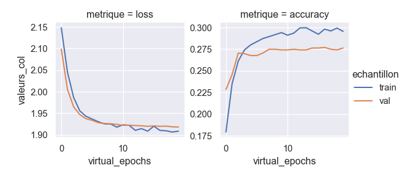

```python
dtf = pd.DataFrame(history_sofmax.history)
colonnes = dtf.columns

dtf = dtf.reset_index().rename(columns = {'index': 'virtual_epochs'})
dtf_tr = pd.melt(dtf, id_vars = ['virtual_epochs'], value_vars = colonnes,
var_name ='noms_col', value_name='valeurs_col')

dtf_tr["metrique"] = dtf_tr.noms_col.str.replace("^val_", "", regex = True)
dtf_tr["echantillon"] = "val"
dtf_tr.loc[dtf_tr.noms_col == dtf_tr.metrique, "echantillon"] = "train"

g = sns.FacetGrid(dtf_tr, col="metrique", hue = "echantillon", sharey = False, col_wrap = 2)
g = g.map_dataframe(sns.lineplot, x = "virtual_epochs",y = "valeurs_col").add_legend()
plt.show()
```

Graphiques des performances du modele binaire selon l’epoque virtuelle.

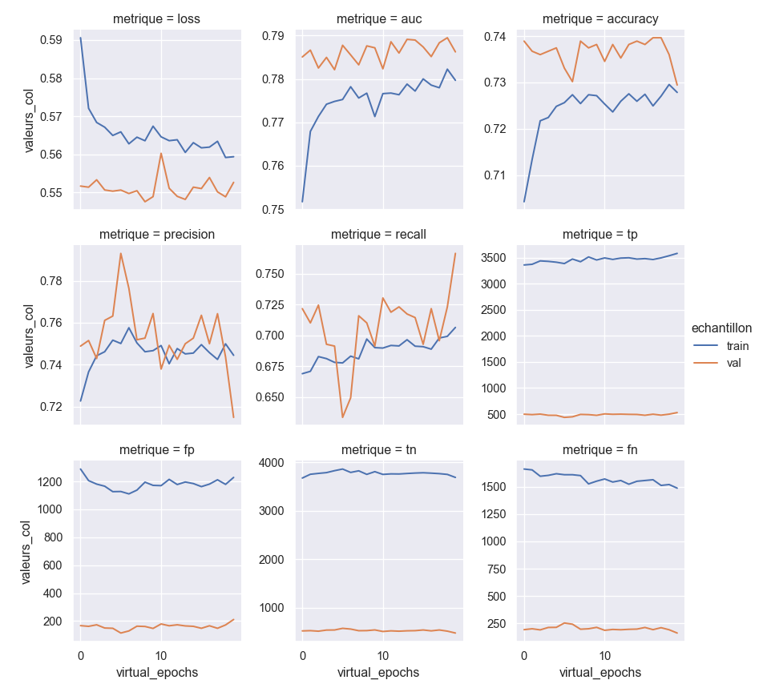

```python
dtf = pd.DataFrame(history_binaire.history)
colonnes = dtf.columns

dtf = dtf.reset_index().rename(columns = {'index': 'virtual_epochs'})
dtf_tr = pd.melt(dtf, id_vars = ['virtual_epochs'], value_vars = colonnes,
var_name ='noms_col', value_name='valeurs_col')

dtf_tr["metrique"] = dtf_tr.noms_col.str.replace("^val_", "", regex = True)
dtf_tr["echantillon"] = "val"
dtf_tr.loc[dtf_tr.noms_col == dtf_tr.metrique, "echantillon"] = "train"

g = sns.FacetGrid(dtf_tr, col="metrique", hue = "echantillon", sharey = False, col_wrap = 3)
g = g.map_dataframe(sns.lineplot, x = "virtual_epochs",y = "valeurs_col").add_legend()
plt.show()
```

Les scores du modele multi-classes.

```python
# on recupere un array numpy
predictions = modele_softmax.predict(test_ds)
predictions.round(2)[:5]

# controle : somme des probas = 1
tf.reduce_sum(tf.nn.softmax(predictions[:5]), axis = 1)
```

```
WARNING:tensorflow:Layers in a Sequential model should only have a single input tensor, but we receive a <class 'dict'> input: {'number_in_household': <tf.Tensor 'ExpandDims_2:0' shape=(None, 1) dtype=int32>, 'marital_status': <tf.Tensor 'ExpandDims_1:0' shape=(None, 1) dtype=string>, 'householder_s…
Consider rewriting this model with the Functional API.
array([[0.01, 0.02, 0.03, 0.05, 0.05, 0.15, 0.17, 0.3 , 0.22],
       [0.12, 0.14, 0.11, 0.15, 0.13, 0.15, 0.11, 0.07, 0.02],
       [0.01, 0.02, 0.03, 0.05, 0.05, 0.15, 0.17, 0.3 , 0.22],
       [0.18, 0.14, 0.11, 0.14, 0.11, 0.13, 0.09, 0.07, 0.03],
       [0.06, 0.09, 0.08, 0.13, 0.12, 0.18, 0.16, 0.14, 0.06]],
      dtype=float32)
<tf.Tensor: shape=(5,), dtype=float32, numpy=array([1., 1., 1., 1., 1.], dtype=float32)>
```

La matrice de confusion du modele multi-classes sur l’echantillon test.

```python
# les previsions, pour chaque exemple on retient la colonne de score maximal
prev = pd.DataFrame(predictions)
prev = list(prev.idxmax(axis = 'columns'))

# le reel (les labels sont la 2eme composante du dataset de test)
reel = pd.concat([pd.DataFrame(dts[1], columns = ["x"]) for dts in iter(test_ds)])

pd.DataFrame({'Y': list(reel.x), 'Ypred': prev}).groupby(["Y", "Ypred"]).size(
).reset_index(name = "nb").pivot(index="Y", columns="Ypred")
```

```
          nb
Ypred      0    1     5      7
Y
0      225.0  3.0  19.0    8.0
1       67.0  1.0  26.0    9.0
2       66.0  2.0  38.0   13.0
3       61.0  3.0  34.0   29.0
4       44.0  1.0  33.0   21.0
5       42.0  1.0  58.0   53.0
6       35.0  NaN  40.0   68.0
7       40.0  NaN  43.0  130.0
8       30.0  NaN  17.0  116.0
```

La matrice de confusion du modele binaire sur l’echantillon test.

```python
prev = modele_binaire.predict(test_ds_bin).squeeze()

# on choisit un seuil : 0.5 par defaut dans les metriques precedentes (vrais positifs, ...)
seuil = 0.5
prev = (prev >= seuil).astype(int)

# le reel
reel = pd.concat([pd.DataFrame(dts[1], columns = ["x"]) for dts in iter(test_ds_bin)])

pd.DataFrame({'Y': list(reel.x), 'Ypred': prev}).groupby(["Y", "Ypred"]).size(
  ).reset_index(name = "nb").pivot(index="Y", columns="Ypred")
```

```
WARNING:tensorflow:Layers in a Sequential model should only have a single input tensor, but we receive a <class 'dict'> input: {'number_in_household': <tf.Tensor 'ExpandDims_2:0' shape=(None, 1) dtype=int32>, 'marital_status': <tf.Tensor 'ExpandDims_1:0' shape=(None, 1) dtype=string>, 'householder_s…
Consider rewriting this model with the Functional API.
        nb
Ypred    0    1
Y
0      516  187
1      169  504
```

# 3 Modelisation multi-classes avec *tf.estimator*

On n’utilise pas l’API Keras cette fois mais *tf.estimator*, ce qui faciliterait l’enchainement de pretraitements, de modelisation et de deploiement sur la Google Cloud Platform.

Fonction de pre-traitement basee sur *pandas_input_fn*.

```python
def make_input_fn(dataframe, shuffle= True, batch_size = TRAIN_BATCH_SIZE,
dico = dico_income, num_epochs= None):
  dataframe = dataframe.copy()
  labels = dataframe.pop('income').map(dico)
  return tf.compat.v1.estimator.inputs.pandas_input_fn(
    x = dataframe,
    y = labels,
    batch_size = batch_size,
    num_epochs = num_epochs,
    shuffle = shuffle,
    queue_capacity = None,
    num_threads = 1
  )
```

On recupere les champs calcules plus haut.

```python
def create_feature_cols():
  return feature_columns.values()
```

On definit deux classifieurs

- le *LinearClassifier* qui est simplement une regression logistique
- le *DNNClassifier* qui est un reseau a plusieus couches cachees

```python
output_dir = os.path.join(os.getcwd(), 'tmp_tensorflow', 'trained_model')

# classifieur lineaire
myopt = tf.compat.v1.train.FtrlOptimizer(learning_rate = 0.2, l1_regularization_strength = 0.1)
estimator_lin = tf.compat.v1.estimator.LinearClassifier(model_dir = output_dir,
n_classes= len(dico_income) ,feature_columns = create_feature_cols(), optimizer = myopt)

# classifieur DNN a 2 couches cachees
estimator_dnn = tf.compat.v1.estimator.DNNClassifier(hidden_units = [16, 8],
model_dir = output_dir, n_classes= len(dico_income) ,feature_columns = create_feature_cols())
```

On precise quelques parametres pour l’apprentissage et le test.

```python
num_train_steps = steps_per_epoch * NUM_CHECKPOINTS

# pour le jeu d'entrainement
train_spec = tf.estimator.TrainSpec(input_fn = make_input_fn(train, shuffle=True, num_epochs=None),
                                    max_steps = num_train_steps)

# pour le jeu de validation, on evalue apres start_delay_secs secondes
# et on evalue toutes les throttle_secs secondes
eval_spec = tf.estimator.EvalSpec(input_fn = make_input_fn(val, shuffle = False, num_epochs = 1),
                                  steps = None,
                                  start_delay_secs = 2,
                                  throttle_secs = 4)
```

On entraine et on evalue les deux modeles.

```python
# on vide le repertoire et on le supprime car il sert aussi de checkpoint
# et son contenu peut etre recharge pour poursuivre l'entrainement
shutil.rmtree(output_dir, ignore_errors = True)
tf.estimator.train_and_evaluate(estimator_lin, train_spec, eval_spec)

shutil.rmtree(output_dir, ignore_errors = True)
tf.estimator.train_and_evaluate(estimator_dnn, train_spec, eval_spec)
```

```
({'accuracy': 0.26763636, 'average_loss': 1.9319504, 'loss': 120.7469, 'global_step': 3120}, [])
```